# Risk Factor Analysis

## Outcome Variable

**Outcome Variable:** y_rate_wtkg

## Predictor Variables

**Intervention Variable:** cleanck

**Adjustment Set:**

unadjusted

## Stratifying Variables

The analysis was stratified on these variable(s):

- agecat
- studyid
- country

## Data Summary

| agecat | studyid | country | cleanck | n_cell | n |
| --- | --- | --- | --- | --- | --- |
| 0-3 months | CMC-V-BCS-2002 | INDIA | 1 | 147 | 331 |
| 0-3 months | CMC-V-BCS-2002 | INDIA | 0 | 184 | 331 |
| 0-3 months | GMS-Nepal | NEPAL | 1 | 7 | 460 |
| 0-3 months | GMS-Nepal | NEPAL | 0 | 453 | 460 |
| 0-3 months | IRC | INDIA | 1 | 223 | 386 |
| 0-3 months | IRC | INDIA | 0 | 163 | 386 |
| 0-3 months | MAL-ED | PERU | 1 | 1 | 1 |
| 0-3 months | MAL-ED | PERU | 0 | 0 | 1 |
| 0-3 months | MAL-ED | SOUTH AFRICA | 1 | 2 | 3 |
| 0-3 months | MAL-ED | SOUTH AFRICA | 0 | 1 | 3 |
| 0-3 months | NIH-Crypto | BANGLADESH | 1 | 337 | 550 |
| 0-3 months | NIH-Crypto | BANGLADESH | 0 | 213 | 550 |
| 0-3 months | PROVIDE | BANGLADESH | 1 | 529 | 640 |
| 0-3 months | PROVIDE | BANGLADESH | 0 | 111 | 640 |
| 3-6 months | CMC-V-BCS-2002 | INDIA | 1 | 138 | 322 |
| 3-6 months | CMC-V-BCS-2002 | INDIA | 0 | 184 | 322 |
| 3-6 months | GMS-Nepal | NEPAL | 1 | 6 | 424 |
| 3-6 months | GMS-Nepal | NEPAL | 0 | 418 | 424 |
| 3-6 months | IRC | INDIA | 1 | 225 | 391 |
| 3-6 months | IRC | INDIA | 0 | 166 | 391 |
| 3-6 months | MAL-ED | SOUTH AFRICA | 1 | 1 | 1 |
| 3-6 months | MAL-ED | SOUTH AFRICA | 0 | 0 | 1 |
| 3-6 months | NIH-Crypto | BANGLADESH | 1 | 320 | 532 |
| 3-6 months | NIH-Crypto | BANGLADESH | 0 | 212 | 532 |
| 3-6 months | PROVIDE | BANGLADESH | 1 | 494 | 601 |
| 3-6 months | PROVIDE | BANGLADESH | 0 | 107 | 601 |
| 6-9 months | CMC-V-BCS-2002 | INDIA | 1 | 141 | 325 |
| 6-9 months | CMC-V-BCS-2002 | INDIA | 0 | 184 | 325 |
| 6-9 months | GMS-Nepal | NEPAL | 1 | 8 | 429 |
| 6-9 months | GMS-Nepal | NEPAL | 0 | 421 | 429 |

[output cut: 68 more lines]

The following strata were considered:

- agecat: 0-3 months, studyid: CMC-V-BCS-2002, country: INDIA
- agecat: 0-3 months, studyid: GMS-Nepal, country: NEPAL
- agecat: 0-3 months, studyid: IRC, country: INDIA
- agecat: 0-3 months, studyid: MAL-ED, country: PERU
- agecat: 0-3 months, studyid: MAL-ED, country: SOUTH AFRICA
- agecat: 0-3 months, studyid: NIH-Crypto, country: BANGLADESH
- agecat: 0-3 months, studyid: PROVIDE, country: BANGLADESH
- agecat: 12-15 months, studyid: CMC-V-BCS-2002, country: INDIA
- agecat: 12-15 months, studyid: GMS-Nepal, country: NEPAL
- agecat: 12-15 months, studyid: IRC, country: INDIA
- agecat: 12-15 months, studyid: MAL-ED, country: SOUTH AFRICA
- agecat: 12-15 months, studyid: NIH-Crypto, country: BANGLADESH
- agecat: 12-15 months, studyid: PROVIDE, country: BANGLADESH
- agecat: 15-18 months, studyid: CMC-V-BCS-2002, country: INDIA
- agecat: 15-18 months, studyid: GMS-Nepal, country: NEPAL
- agecat: 15-18 months, studyid: IRC, country: INDIA
- agecat: 15-18 months, studyid: MAL-ED, country: SOUTH AFRICA
- agecat: 15-18 months, studyid: NIH-Crypto, country: BANGLADESH
- agecat: 15-18 months, studyid: PROVIDE, country: BANGLADESH
- agecat: 18-21 months, studyid: CMC-V-BCS-2002, country: INDIA
- agecat: 18-21 months, studyid: GMS-Nepal, country: NEPAL
- agecat: 18-21 months, studyid: IRC, country: INDIA
- agecat: 18-21 months, studyid: MAL-ED, country: SOUTH AFRICA
- agecat: 18-21 months, studyid: NIH-Crypto, country: BANGLADESH
- agecat: 18-21 months, studyid: PROVIDE, country: BANGLADESH
- agecat: 21-24 months, studyid: CMC-V-BCS-2002, country: INDIA
- agecat: 21-24 months, studyid: GMS-Nepal, country: NEPAL
- agecat: 21-24 months, studyid: IRC, country: INDIA
- agecat: 21-24 months, studyid: MAL-ED, country: SOUTH AFRICA
- agecat: 21-24 months, studyid: NIH-Crypto, country: BANGLADESH
- agecat: 21-24 months, studyid: PROVIDE, country: BANGLADESH
- agecat: 3-6 months, studyid: CMC-V-BCS-2002, country: INDIA
- agecat: 3-6 months, studyid: GMS-Nepal, country: NEPAL
- agecat: 3-6 months, studyid: IRC, country: INDIA
- agecat: 3-6 months, studyid: MAL-ED, country: SOUTH AFRICA
- agecat: 3-6 months, studyid: NIH-Crypto, country: BANGLADESH
- agecat: 3-6 months, studyid: PROVIDE, country: BANGLADESH
- agecat: 6-9 months, studyid: CMC-V-BCS-2002, country: INDIA
- agecat: 6-9 months, studyid: GMS-Nepal, country: NEPAL
- agecat: 6-9 months, studyid: IRC, country: INDIA
- agecat: 6-9 months, studyid: MAL-ED, country: SOUTH AFRICA
- agecat: 6-9 months, studyid: NIH-Crypto, country: BANGLADESH
- agecat: 6-9 months, studyid: PROVIDE, country: BANGLADESH
- agecat: 9-12 months, studyid: CMC-V-BCS-2002, country: INDIA
- agecat: 9-12 months, studyid: GMS-Nepal, country: NEPAL
- agecat: 9-12 months, studyid: IRC, country: INDIA
- agecat: 9-12 months, studyid: MAL-ED, country: SOUTH AFRICA
- agecat: 9-12 months, studyid: NIH-Crypto, country: BANGLADESH
- agecat: 9-12 months, studyid: PROVIDE, country: BANGLADESH

### Dropped Strata

Some strata were dropped due to rare outcomes:

- agecat: 0-3 months, studyid: MAL-ED, country: PERU
- agecat: 0-3 months, studyid: MAL-ED, country: SOUTH AFRICA
- agecat: 3-6 months, studyid: MAL-ED, country: SOUTH AFRICA
- agecat: 6-9 months, studyid: MAL-ED, country: SOUTH AFRICA
- agecat: 9-12 months, studyid: MAL-ED, country: SOUTH AFRICA
- agecat: 12-15 months, studyid: MAL-ED, country: SOUTH AFRICA
- agecat: 15-18 months, studyid: MAL-ED, country: SOUTH AFRICA
- agecat: 18-21 months, studyid: MAL-ED, country: SOUTH AFRICA
- agecat: 21-24 months, studyid: GMS-Nepal, country: NEPAL
- agecat: 21-24 months, studyid: MAL-ED, country: SOUTH AFRICA

## Methods Detail

We’re interested in the causal parameters $E[Y_a]$ for all values of $a \in \mathcal{A}$. These parameters represent the mean outcome if, possibly contrary to fact, we intervened to set all units to have $A=a$. Under the randomization and positivity assumptions, these are identified by the statistical parameters $\psi_a=E_W[E_{Y|A,W}(Y|A=a,W)]$. In addition, we’re interested in the mean of $Y$, $E[Y]$ under no intervention (the observed mean). We will estimate these parameters by using SuperLearner to fit the relevant likelihood factors – $E_{Y|A,W}(Y|A=a,W)$ and $p(A=a|W)$, and then updating our likelihood fit using a joint TMLE.

For unadjusted analyses ($W=\{\}$), initial likelihoods were estimated using Lrnr_glm to estimate the simple $E(Y|A)$ and Lrnr_mean to estimate $p(A)$. For adjusted analyses, a small library containing Lrnr_glmnet, Lrnr_xgboost, and Lrnr_mean was used.

# Results Detail

## Results Plots

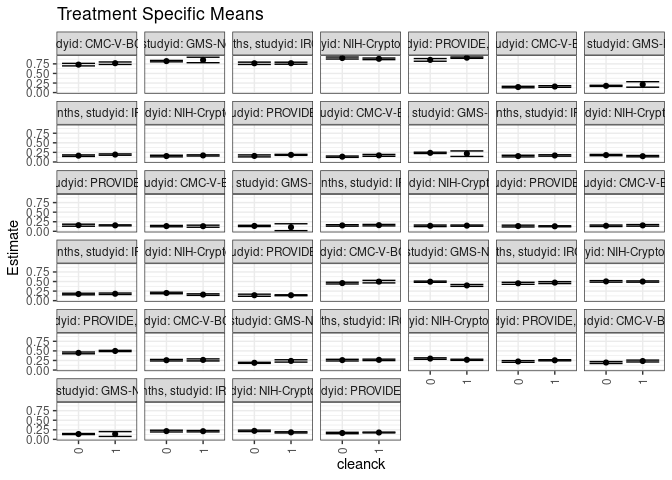

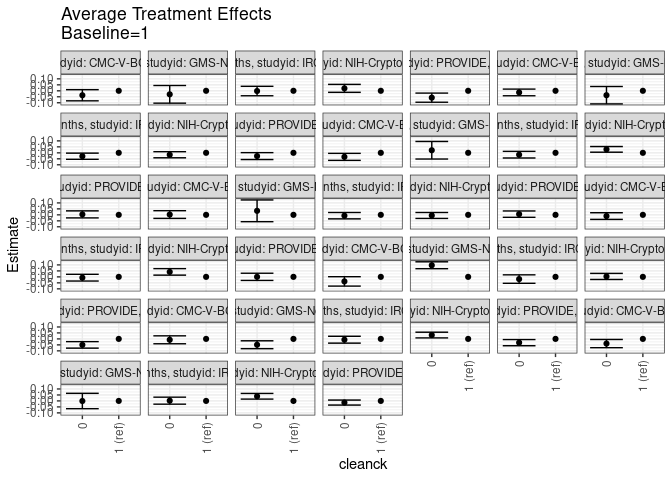

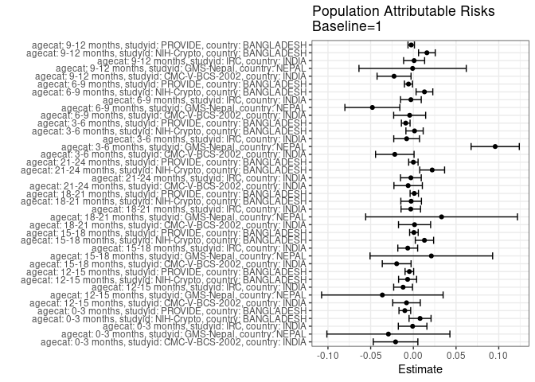

## Results Table

### Parameter: TSM

| agecat | studyid | country | intervention_level | baseline_level | estimate | ci_lower | ci_upper |
| --- | --- | --- | --- | --- | --- | --- | --- |
| 0-3 months | CMC-V-BCS-2002 | INDIA | 1 | NA | 0.7675616 | 0.7348516 | 0.8002717 |
| 0-3 months | CMC-V-BCS-2002 | INDIA | 0 | NA | 0.7301339 | 0.6966652 | 0.7636026 |
| 0-3 months | GMS-Nepal | NEPAL | 1 | NA | 0.8517935 | 0.7801961 | 0.9233909 |
| 0-3 months | GMS-Nepal | NEPAL | 0 | NA | 0.8221249 | 0.8038873 | 0.8403626 |
| 0-3 months | IRC | INDIA | 1 | NA | 0.7677833 | 0.7417638 | 0.7938029 |
| 0-3 months | IRC | INDIA | 0 | NA | 0.7657744 | 0.7358643 | 0.7956846 |
| 0-3 months | NIH-Crypto | BANGLADESH | 1 | NA | 0.8822415 | 0.8614335 | 0.9030494 |
| 0-3 months | NIH-Crypto | BANGLADESH | 0 | NA | 0.9025430 | 0.8766778 | 0.9284082 |
| 0-3 months | PROVIDE | BANGLADESH | 1 | NA | 0.9116266 | 0.8954527 | 0.9278006 |
| 0-3 months | PROVIDE | BANGLADESH | 0 | NA | 0.8540874 | 0.8194185 | 0.8887563 |
| 3-6 months | CMC-V-BCS-2002 | INDIA | 1 | NA | 0.4968670 | 0.4643287 | 0.5294053 |
| 3-6 months | CMC-V-BCS-2002 | INDIA | 0 | NA | 0.4588739 | 0.4368077 | 0.4809402 |
| 3-6 months | GMS-Nepal | NEPAL | 1 | NA | 0.3977899 | 0.3730672 | 0.4225126 |
| 3-6 months | GMS-Nepal | NEPAL | 0 | NA | 0.4950234 | 0.4799980 | 0.5100489 |
| 3-6 months | IRC | INDIA | 1 | NA | 0.4718594 | 0.4476031 | 0.4961156 |
| 3-6 months | IRC | INDIA | 0 | NA | 0.4533795 | 0.4274937 | 0.4792653 |
| 3-6 months | NIH-Crypto | BANGLADESH | 1 | NA | 0.4997578 | 0.4835673 | 0.5159484 |
| 3-6 months | NIH-Crypto | BANGLADESH | 0 | NA | 0.5033056 | 0.4837380 | 0.5228731 |
| 3-6 months | PROVIDE | BANGLADESH | 1 | NA | 0.4979860 | 0.4829962 | 0.5129757 |
| 3-6 months | PROVIDE | BANGLADESH | 0 | NA | 0.4478567 | 0.4251973 | 0.4705162 |
| 6-9 months | CMC-V-BCS-2002 | INDIA | 1 | NA | 0.2638932 | 0.2374878 | 0.2902986 |
| 6-9 months | CMC-V-BCS-2002 | INDIA | 0 | NA | 0.2562905 | 0.2363645 | 0.2762165 |
| 6-9 months | GMS-Nepal | NEPAL | 1 | NA | 0.2373516 | 0.2071781 | 0.2675251 |
| 6-9 months | GMS-Nepal | NEPAL | 0 | NA | 0.1884564 | 0.1750948 | 0.2018179 |
| 6-9 months | IRC | INDIA | 1 | NA | 0.2654751 | 0.2471082 | 0.2838420 |
| 6-9 months | IRC | INDIA | 0 | NA | 0.2586682 | 0.2366360 | 0.2807003 |
| 6-9 months | NIH-Crypto | BANGLADESH | 1 | NA | 0.2669247 | 0.2519287 | 0.2819207 |
| 6-9 months | NIH-Crypto | BANGLADESH | 0 | NA | 0.2990674 | 0.2803777 | 0.3177572 |
| 6-9 months | PROVIDE | BANGLADESH | 1 | NA | 0.2548471 | 0.2409874 | 0.2687067 |
| 6-9 months | PROVIDE | BANGLADESH | 0 | NA | 0.2233789 | 0.2017273 | 0.2450305 |
| 9-12 months | CMC-V-BCS-2002 | INDIA | 1 | NA | 0.2349137 | 0.2104896 | 0.2593378 |
| 9-12 months | CMC-V-BCS-2002 | INDIA | 0 | NA | 0.1956339 | 0.1714157 | 0.2198522 |
| 9-12 months | GMS-Nepal | NEPAL | 1 | NA | 0.1404390 | 0.0774489 | 0.2034290 |
| 9-12 months | GMS-Nepal | NEPAL | 0 | NA | 0.1395699 | 0.1259592 | 0.1531806 |
| 9-12 months | IRC | INDIA | 1 | NA | 0.2139673 | 0.1955235 | 0.2324111 |
| 9-12 months | IRC | INDIA | 0 | NA | 0.2161472 | 0.1933842 | 0.2389103 |
| 9-12 months | NIH-Crypto | BANGLADESH | 1 | NA | 0.1839144 | 0.1685546 | 0.1992743 |
| 9-12 months | NIH-Crypto | BANGLADESH | 0 | NA | 0.2227828 | 0.2048136 | 0.2407521 |
| 9-12 months | PROVIDE | BANGLADESH | 1 | NA | 0.1800171 | 0.1693566 | 0.1906777 |
| 9-12 months | PROVIDE | BANGLADESH | 0 | NA | 0.1661518 | 0.1481672 | 0.1841363 |
| 12-15 months | CMC-V-BCS-2002 | INDIA | 1 | NA | 0.1584629 | 0.1377782 | 0.1791475 |
| 12-15 months | CMC-V-BCS-2002 | INDIA | 0 | NA | 0.1446964 | 0.1262338 | 0.1631591 |
| 12-15 months | GMS-Nepal | NEPAL | 1 | NA | 0.2124379 | 0.1407820 | 0.2840939 |
| 12-15 months | GMS-Nepal | NEPAL | 0 | NA | 0.1754264 | 0.1615923 | 0.1892604 |
| 12-15 months | IRC | INDIA | 1 | NA | 0.1927295 | 0.1753294 | 0.2101296 |
| 12-15 months | IRC | INDIA | 0 | NA | 0.1642165 | 0.1450448 | 0.1833882 |
| 12-15 months | NIH-Crypto | BANGLADESH | 1 | NA | 0.1701572 | 0.1548862 | 0.1854282 |
| 12-15 months | NIH-Crypto | BANGLADESH | 0 | NA | 0.1539395 | 0.1335848 | 0.1742942 |
| 12-15 months | PROVIDE | BANGLADESH | 1 | NA | 0.1847031 | 0.1716664 | 0.1977399 |
| 12-15 months | PROVIDE | BANGLADESH | 0 | NA | 0.1574401 | 0.1316358 | 0.1832444 |
| 15-18 months | CMC-V-BCS-2002 | INDIA | 1 | NA | 0.1717109 | 0.1480883 | 0.1953335 |
| 15-18 months | CMC-V-BCS-2002 | INDIA | 0 | NA | 0.1377729 | 0.1207090 | 0.1548368 |
| 15-18 months | GMS-Nepal | NEPAL | 1 | NA | 0.2159802 | 0.1441626 | 0.2877979 |
| 15-18 months | GMS-Nepal | NEPAL | 0 | NA | 0.2374486 | 0.2212279 | 0.2536693 |
| 15-18 months | IRC | INDIA | 1 | NA | 0.1687236 | 0.1510410 | 0.1864062 |
| 15-18 months | IRC | INDIA | 0 | NA | 0.1530285 | 0.1317420 | 0.1743150 |
| 15-18 months | NIH-Crypto | BANGLADESH | 1 | NA | 0.1506981 | 0.1338622 | 0.1675339 |
| 15-18 months | NIH-Crypto | BANGLADESH | 0 | NA | 0.1795996 | 0.1629238 | 0.1962753 |
| 15-18 months | PROVIDE | BANGLADESH | 1 | NA | 0.1556949 | 0.1425774 | 0.1688123 |
| 15-18 months | PROVIDE | BANGLADESH | 0 | NA | 0.1595406 | 0.1332366 | 0.1858446 |
| 18-21 months | CMC-V-BCS-2002 | INDIA | 1 | NA | 0.1338151 | 0.1067140 | 0.1609161 |
| 18-21 months | CMC-V-BCS-2002 | INDIA | 0 | NA | 0.1362431 | 0.1188285 | 0.1536577 |
| 18-21 months | GMS-Nepal | NEPAL | 1 | NA | 0.1069112 | 0.0173514 | 0.1964710 |
| 18-21 months | GMS-Nepal | NEPAL | 0 | NA | 0.1405466 | 0.1237035 | 0.1573898 |
| 18-21 months | IRC | INDIA | 1 | NA | 0.1606717 | 0.1416039 | 0.1797396 |
| 18-21 months | IRC | INDIA | 0 | NA | 0.1536250 | 0.1349620 | 0.1722881 |
| 18-21 months | NIH-Crypto | BANGLADESH | 1 | NA | 0.1485909 | 0.1333071 | 0.1638747 |
| 18-21 months | NIH-Crypto | BANGLADESH | 0 | NA | 0.1432675 | 0.1236698 | 0.1628652 |
| 18-21 months | PROVIDE | BANGLADESH | 1 | NA | 0.1313933 | 0.1183671 | 0.1444195 |
| 18-21 months | PROVIDE | BANGLADESH | 0 | NA | 0.1373276 | 0.1142737 | 0.1603814 |
| 21-24 months | CMC-V-BCS-2002 | INDIA | 1 | NA | 0.1545407 | 0.1337473 | 0.1753341 |
| 21-24 months | CMC-V-BCS-2002 | INDIA | 0 | NA | 0.1443002 | 0.1256076 | 0.1629928 |
| 21-24 months | IRC | INDIA | 1 | NA | 0.1804138 | 0.1614289 | 0.1993988 |
| 21-24 months | IRC | INDIA | 0 | NA | 0.1737257 | 0.1529853 | 0.1944661 |
| 21-24 months | NIH-Crypto | BANGLADESH | 1 | NA | 0.1587891 | 0.1395737 | 0.1780046 |
| 21-24 months | NIH-Crypto | BANGLADESH | 0 | NA | 0.2004621 | 0.1811775 | 0.2197466 |
| 21-24 months | PROVIDE | BANGLADESH | 1 | NA | 0.1419217 | 0.1293192 | 0.1545241 |
| 21-24 months | PROVIDE | BANGLADESH | 0 | NA | 0.1421877 | 0.1149818 | 0.1693935 |

### Parameter: E(Y)

| agecat | studyid | country | intervention_level | baseline_level | estimate | ci_lower | ci_upper |
| --- | --- | --- | --- | --- | --- | --- | --- |
| 0-3 months | CMC-V-BCS-2002 | INDIA | NA | NA | 0.7467559 | 0.7230662 | 0.7704455 |
| 0-3 months | GMS-Nepal | NEPAL | NA | NA | 0.8225764 | 0.8047018 | 0.8404511 |
| 0-3 months | IRC | INDIA | NA | NA | 0.7669350 | 0.7473009 | 0.7865692 |
| 0-3 months | NIH-Crypto | BANGLADESH | NA | NA | 0.8901037 | 0.8738687 | 0.9063387 |
| 0-3 months | PROVIDE | BANGLADESH | NA | NA | 0.9016472 | 0.8868914 | 0.9164029 |
| 3-6 months | CMC-V-BCS-2002 | INDIA | NA | NA | 0.4751567 | 0.4562440 | 0.4940693 |
| 3-6 months | GMS-Nepal | NEPAL | NA | NA | 0.4936475 | 0.4789438 | 0.5083512 |
| 3-6 months | IRC | INDIA | NA | NA | 0.4640137 | 0.4462252 | 0.4818022 |
| 3-6 months | NIH-Crypto | BANGLADESH | NA | NA | 0.5011716 | 0.4886950 | 0.5136482 |
| 3-6 months | PROVIDE | BANGLADESH | NA | NA | 0.4890611 | 0.4760060 | 0.5021163 |
| 6-9 months | CMC-V-BCS-2002 | INDIA | NA | NA | 0.2595889 | 0.2435057 | 0.2756721 |
| 6-9 months | GMS-Nepal | NEPAL | NA | NA | 0.1893682 | 0.1763037 | 0.2024326 |
| 6-9 months | IRC | INDIA | NA | NA | 0.2625992 | 0.2484830 | 0.2767153 |
| 6-9 months | NIH-Crypto | BANGLADESH | NA | NA | 0.2799276 | 0.2681500 | 0.2917053 |
| 6-9 months | PROVIDE | BANGLADESH | NA | NA | 0.2491653 | 0.2371134 | 0.2612172 |
| 9-12 months | CMC-V-BCS-2002 | INDIA | NA | NA | 0.2123308 | 0.1948351 | 0.2298265 |
| 9-12 months | GMS-Nepal | NEPAL | NA | NA | 0.1395867 | 0.1262232 | 0.1529503 |
| 9-12 months | IRC | INDIA | NA | NA | 0.2148825 | 0.2005353 | 0.2292297 |
| 9-12 months | NIH-Crypto | BANGLADESH | NA | NA | 0.1997882 | 0.1879938 | 0.2115826 |
| 9-12 months | PROVIDE | BANGLADESH | NA | NA | 0.1775316 | 0.1681968 | 0.1868664 |
| 12-15 months | CMC-V-BCS-2002 | INDIA | NA | NA | 0.1504668 | 0.1366572 | 0.1642764 |
| 12-15 months | GMS-Nepal | NEPAL | NA | NA | 0.1761486 | 0.1625329 | 0.1897642 |
| 12-15 months | IRC | INDIA | NA | NA | 0.1807123 | 0.1677267 | 0.1936978 |
| 12-15 months | NIH-Crypto | BANGLADESH | NA | NA | 0.1634289 | 0.1511149 | 0.1757429 |
| 12-15 months | PROVIDE | BANGLADESH | NA | NA | 0.1800324 | 0.1683272 | 0.1917375 |
| 15-18 months | CMC-V-BCS-2002 | INDIA | NA | NA | 0.1521835 | 0.1380291 | 0.1663379 |
| 15-18 months | GMS-Nepal | NEPAL | NA | NA | 0.2370510 | 0.2211319 | 0.2529701 |
| 15-18 months | IRC | INDIA | NA | NA | 0.1621526 | 0.1485252 | 0.1757800 |
| 15-18 months | NIH-Crypto | BANGLADESH | NA | NA | 0.1636945 | 0.1517037 | 0.1756852 |
| 15-18 months | PROVIDE | BANGLADESH | NA | NA | 0.1563514 | 0.1445823 | 0.1681205 |
| 18-21 months | CMC-V-BCS-2002 | INDIA | NA | NA | 0.1352327 | 0.1200477 | 0.1504178 |
| 18-21 months | GMS-Nepal | NEPAL | NA | NA | 0.1399681 | 0.1233886 | 0.1565477 |
| 18-21 months | IRC | INDIA | NA | NA | 0.1576598 | 0.1441337 | 0.1711860 |
| 18-21 months | NIH-Crypto | BANGLADESH | NA | NA | 0.1460095 | 0.1336664 | 0.1583525 |
| 18-21 months | PROVIDE | BANGLADESH | NA | NA | 0.1324882 | 0.1210438 | 0.1439326 |
| 21-24 months | CMC-V-BCS-2002 | INDIA | NA | NA | 0.1484491 | 0.1344875 | 0.1624106 |
| 21-24 months | IRC | INDIA | NA | NA | 0.1775274 | 0.1635028 | 0.1915520 |
| 21-24 months | NIH-Crypto | BANGLADESH | NA | NA | 0.1808389 | 0.1670473 | 0.1946304 |
| 21-24 months | PROVIDE | BANGLADESH | NA | NA | 0.1419705 | 0.1305335 | 0.1534075 |

### Parameter: ATE

| agecat | studyid | country | intervention_level | baseline_level | estimate | ci_lower | ci_upper |
| --- | --- | --- | --- | --- | --- | --- | --- |
| 0-3 months | CMC-V-BCS-2002 | INDIA | 1 | 1 | 0.0000000 | 0.0000000 | 0.0000000 |
| 0-3 months | CMC-V-BCS-2002 | INDIA | 0 | 1 | -0.0374277 | -0.0842263 | 0.0093708 |
| 0-3 months | GMS-Nepal | NEPAL | 1 | 1 | 0.0000000 | 0.0000000 | 0.0000000 |
| 0-3 months | GMS-Nepal | NEPAL | 0 | 1 | -0.0296686 | -0.1035523 | 0.0442151 |
| 0-3 months | IRC | INDIA | 1 | 1 | 0.0000000 | 0.0000000 | 0.0000000 |
| 0-3 months | IRC | INDIA | 0 | 1 | -0.0020089 | -0.0416527 | 0.0376350 |
| 0-3 months | NIH-Crypto | BANGLADESH | 1 | 1 | 0.0000000 | 0.0000000 | 0.0000000 |
| 0-3 months | NIH-Crypto | BANGLADESH | 0 | 1 | 0.0203015 | -0.0128946 | 0.0534976 |
| 0-3 months | PROVIDE | BANGLADESH | 1 | 1 | 0.0000000 | 0.0000000 | 0.0000000 |
| 0-3 months | PROVIDE | BANGLADESH | 0 | 1 | -0.0575392 | -0.0957953 | -0.0192831 |
| 3-6 months | CMC-V-BCS-2002 | INDIA | 1 | 1 | 0.0000000 | 0.0000000 | 0.0000000 |
| 3-6 months | CMC-V-BCS-2002 | INDIA | 0 | 1 | -0.0379931 | -0.0773080 | 0.0013218 |
| 3-6 months | GMS-Nepal | NEPAL | 1 | 1 | 0.0000000 | 0.0000000 | 0.0000000 |
| 3-6 months | GMS-Nepal | NEPAL | 0 | 1 | 0.0972335 | 0.0683030 | 0.1261641 |
| 3-6 months | IRC | INDIA | 1 | 1 | 0.0000000 | 0.0000000 | 0.0000000 |
| 3-6 months | IRC | INDIA | 0 | 1 | -0.0184799 | -0.0539544 | 0.0169946 |
| 3-6 months | NIH-Crypto | BANGLADESH | 1 | 1 | 0.0000000 | 0.0000000 | 0.0000000 |
| 3-6 months | NIH-Crypto | BANGLADESH | 0 | 1 | 0.0035477 | -0.0218496 | 0.0289450 |
| 3-6 months | PROVIDE | BANGLADESH | 1 | 1 | 0.0000000 | 0.0000000 | 0.0000000 |
| 3-6 months | PROVIDE | BANGLADESH | 0 | 1 | -0.0501292 | -0.0772980 | -0.0229604 |
| 6-9 months | CMC-V-BCS-2002 | INDIA | 1 | 1 | 0.0000000 | 0.0000000 | 0.0000000 |
| 6-9 months | CMC-V-BCS-2002 | INDIA | 0 | 1 | -0.0076027 | -0.0406827 | 0.0254773 |
| 6-9 months | GMS-Nepal | NEPAL | 1 | 1 | 0.0000000 | 0.0000000 | 0.0000000 |
| 6-9 months | GMS-Nepal | NEPAL | 0 | 1 | -0.0488953 | -0.0818949 | -0.0158957 |
| 6-9 months | IRC | INDIA | 1 | 1 | 0.0000000 | 0.0000000 | 0.0000000 |
| 6-9 months | IRC | INDIA | 0 | 1 | -0.0068069 | -0.0354907 | 0.0218769 |
| 6-9 months | NIH-Crypto | BANGLADESH | 1 | 1 | 0.0000000 | 0.0000000 | 0.0000000 |
| 6-9 months | NIH-Crypto | BANGLADESH | 0 | 1 | 0.0321427 | 0.0081805 | 0.0561049 |
| 6-9 months | PROVIDE | BANGLADESH | 1 | 1 | 0.0000000 | 0.0000000 | 0.0000000 |
| 6-9 months | PROVIDE | BANGLADESH | 0 | 1 | -0.0314682 | -0.0571758 | -0.0057605 |
| 9-12 months | CMC-V-BCS-2002 | INDIA | 1 | 1 | 0.0000000 | 0.0000000 | 0.0000000 |
| 9-12 months | CMC-V-BCS-2002 | INDIA | 0 | 1 | -0.0392798 | -0.0736754 | -0.0048842 |
| 9-12 months | GMS-Nepal | NEPAL | 1 | 1 | 0.0000000 | 0.0000000 | 0.0000000 |
| 9-12 months | GMS-Nepal | NEPAL | 0 | 1 | -0.0008691 | -0.0653129 | 0.0635747 |
| 9-12 months | IRC | INDIA | 1 | 1 | 0.0000000 | 0.0000000 | 0.0000000 |
| 9-12 months | IRC | INDIA | 0 | 1 | 0.0021799 | -0.0271173 | 0.0314772 |
| 9-12 months | NIH-Crypto | BANGLADESH | 1 | 1 | 0.0000000 | 0.0000000 | 0.0000000 |
| 9-12 months | NIH-Crypto | BANGLADESH | 0 | 1 | 0.0388684 | 0.0152291 | 0.0625077 |
| 9-12 months | PROVIDE | BANGLADESH | 1 | 1 | 0.0000000 | 0.0000000 | 0.0000000 |
| 9-12 months | PROVIDE | BANGLADESH | 0 | 1 | -0.0138654 | -0.0347721 | 0.0070414 |
| 12-15 months | CMC-V-BCS-2002 | INDIA | 1 | 1 | 0.0000000 | 0.0000000 | 0.0000000 |
| 12-15 months | CMC-V-BCS-2002 | INDIA | 0 | 1 | -0.0137665 | -0.0414923 | 0.0139594 |
| 12-15 months | GMS-Nepal | NEPAL | 1 | 1 | 0.0000000 | 0.0000000 | 0.0000000 |
| 12-15 months | GMS-Nepal | NEPAL | 0 | 1 | -0.0370116 | -0.1099908 | 0.0359676 |
| 12-15 months | IRC | INDIA | 1 | 1 | 0.0000000 | 0.0000000 | 0.0000000 |
| 12-15 months | IRC | INDIA | 0 | 1 | -0.0285130 | -0.0544035 | -0.0026225 |
| 12-15 months | NIH-Crypto | BANGLADESH | 1 | 1 | 0.0000000 | 0.0000000 | 0.0000000 |
| 12-15 months | NIH-Crypto | BANGLADESH | 0 | 1 | -0.0162177 | -0.0416640 | 0.0092287 |
| 12-15 months | PROVIDE | BANGLADESH | 1 | 1 | 0.0000000 | 0.0000000 | 0.0000000 |
| 12-15 months | PROVIDE | BANGLADESH | 0 | 1 | -0.0272630 | -0.0561736 | 0.0016475 |
| 15-18 months | CMC-V-BCS-2002 | INDIA | 1 | 1 | 0.0000000 | 0.0000000 | 0.0000000 |
| 15-18 months | CMC-V-BCS-2002 | INDIA | 0 | 1 | -0.0339380 | -0.0630791 | -0.0047969 |
| 15-18 months | GMS-Nepal | NEPAL | 1 | 1 | 0.0000000 | 0.0000000 | 0.0000000 |
| 15-18 months | GMS-Nepal | NEPAL | 0 | 1 | 0.0214684 | -0.0521583 | 0.0950951 |
| 15-18 months | IRC | INDIA | 1 | 1 | 0.0000000 | 0.0000000 | 0.0000000 |
| 15-18 months | IRC | INDIA | 0 | 1 | -0.0156951 | -0.0433680 | 0.0119778 |
| 15-18 months | NIH-Crypto | BANGLADESH | 1 | 1 | 0.0000000 | 0.0000000 | 0.0000000 |
| 15-18 months | NIH-Crypto | BANGLADESH | 0 | 1 | 0.0289015 | 0.0052050 | 0.0525980 |
| 15-18 months | PROVIDE | BANGLADESH | 1 | 1 | 0.0000000 | 0.0000000 | 0.0000000 |
| 15-18 months | PROVIDE | BANGLADESH | 0 | 1 | 0.0038457 | -0.0255476 | 0.0332390 |
| 18-21 months | CMC-V-BCS-2002 | INDIA | 1 | 1 | 0.0000000 | 0.0000000 | 0.0000000 |
| 18-21 months | CMC-V-BCS-2002 | INDIA | 0 | 1 | 0.0024280 | -0.0297858 | 0.0346419 |
| 18-21 months | GMS-Nepal | NEPAL | 1 | 1 | 0.0000000 | 0.0000000 | 0.0000000 |
| 18-21 months | GMS-Nepal | NEPAL | 0 | 1 | 0.0336355 | -0.0574944 | 0.1247653 |
| 18-21 months | IRC | INDIA | 1 | 1 | 0.0000000 | 0.0000000 | 0.0000000 |
| 18-21 months | IRC | INDIA | 0 | 1 | -0.0070467 | -0.0337280 | 0.0196346 |
| 18-21 months | NIH-Crypto | BANGLADESH | 1 | 1 | 0.0000000 | 0.0000000 | 0.0000000 |
| 18-21 months | NIH-Crypto | BANGLADESH | 0 | 1 | -0.0053234 | -0.0301763 | 0.0195295 |
| 18-21 months | PROVIDE | BANGLADESH | 1 | 1 | 0.0000000 | 0.0000000 | 0.0000000 |
| 18-21 months | PROVIDE | BANGLADESH | 0 | 1 | 0.0059343 | -0.0205452 | 0.0324137 |
| 21-24 months | CMC-V-BCS-2002 | INDIA | 1 | 1 | 0.0000000 | 0.0000000 | 0.0000000 |
| 21-24 months | CMC-V-BCS-2002 | INDIA | 0 | 1 | -0.0102405 | -0.0382008 | 0.0177198 |
| 21-24 months | IRC | INDIA | 1 | 1 | 0.0000000 | 0.0000000 | 0.0000000 |
| 21-24 months | IRC | INDIA | 0 | 1 | -0.0066881 | -0.0348056 | 0.0214294 |
| 21-24 months | NIH-Crypto | BANGLADESH | 1 | 1 | 0.0000000 | 0.0000000 | 0.0000000 |
| 21-24 months | NIH-Crypto | BANGLADESH | 0 | 1 | 0.0416729 | 0.0144493 | 0.0688966 |
| 21-24 months | PROVIDE | BANGLADESH | 1 | 1 | 0.0000000 | 0.0000000 | 0.0000000 |
| 21-24 months | PROVIDE | BANGLADESH | 0 | 1 | 0.0002660 | -0.0297170 | 0.0302491 |

### Parameter: PAR

| agecat | studyid | country | intervention_level | baseline_level | estimate | ci_lower | ci_upper |
| --- | --- | --- | --- | --- | --- | --- | --- |
| 0-3 months | CMC-V-BCS-2002 | INDIA | 1 | NA | -0.0208057 | -0.0468979 | 0.0052864 |
| 0-3 months | GMS-Nepal | NEPAL | 1 | NA | -0.0292171 | -0.1012545 | 0.0428203 |
| 0-3 months | IRC | INDIA | 1 | NA | -0.0008483 | -0.0175894 | 0.0158928 |
| 0-3 months | NIH-Crypto | BANGLADESH | 1 | NA | 0.0078622 | -0.0050203 | 0.0207448 |
| 0-3 months | PROVIDE | BANGLADESH | 1 | NA | -0.0099795 | -0.0168261 | -0.0031328 |
| 3-6 months | CMC-V-BCS-2002 | INDIA | 1 | NA | -0.0217103 | -0.0442699 | 0.0008493 |
| 3-6 months | GMS-Nepal | NEPAL | 1 | NA | 0.0958576 | 0.0676291 | 0.1240861 |
| 3-6 months | IRC | INDIA | 1 | NA | -0.0078457 | -0.0229337 | 0.0072424 |
| 3-6 months | NIH-Crypto | BANGLADESH | 1 | NA | 0.0014138 | -0.0087081 | 0.0115356 |
| 3-6 months | PROVIDE | BANGLADESH | 1 | NA | -0.0089248 | -0.0139994 | -0.0038503 |
| 6-9 months | CMC-V-BCS-2002 | INDIA | 1 | NA | -0.0043043 | -0.0230372 | 0.0144286 |
| 6-9 months | GMS-Nepal | NEPAL | 1 | NA | -0.0479835 | -0.0801642 | -0.0158028 |
| 6-9 months | IRC | INDIA | 1 | NA | -0.0028759 | -0.0149993 | 0.0092475 |
| 6-9 months | NIH-Crypto | BANGLADESH | 1 | NA | 0.0130029 | 0.0032164 | 0.0227895 |
| 6-9 months | PROVIDE | BANGLADESH | 1 | NA | -0.0056818 | -0.0104277 | -0.0009358 |
| 9-12 months | CMC-V-BCS-2002 | INDIA | 1 | NA | -0.0225829 | -0.0424698 | -0.0026960 |
| 9-12 months | GMS-Nepal | NEPAL | 1 | NA | -0.0008522 | -0.0636849 | 0.0619804 |
| 9-12 months | IRC | INDIA | 1 | NA | 0.0009152 | -0.0113856 | 0.0132161 |
| 9-12 months | NIH-Crypto | BANGLADESH | 1 | NA | 0.0158737 | 0.0060816 | 0.0256658 |
| 9-12 months | PROVIDE | BANGLADESH | 1 | NA | -0.0024855 | -0.0062587 | 0.0012877 |
| 12-15 months | CMC-V-BCS-2002 | INDIA | 1 | NA | -0.0079961 | -0.0241168 | 0.0081247 |
| 12-15 months | GMS-Nepal | NEPAL | 1 | NA | -0.0362894 | -0.1074458 | 0.0348670 |
| 12-15 months | IRC | INDIA | 1 | NA | -0.0120173 | -0.0230204 | -0.0010141 |
| 12-15 months | NIH-Crypto | BANGLADESH | 1 | NA | -0.0067283 | -0.0173080 | 0.0038515 |
| 12-15 months | PROVIDE | BANGLADESH | 1 | NA | -0.0046708 | -0.0096995 | 0.0003580 |
| 15-18 months | CMC-V-BCS-2002 | INDIA | 1 | NA | -0.0195274 | -0.0363939 | -0.0026609 |
| 15-18 months | GMS-Nepal | NEPAL | 1 | NA | 0.0210708 | -0.0507157 | 0.0928573 |
| 15-18 months | IRC | INDIA | 1 | NA | -0.0065710 | -0.0181833 | 0.0050413 |
| 15-18 months | NIH-Crypto | BANGLADESH | 1 | NA | 0.0129964 | 0.0022609 | 0.0237319 |
| 15-18 months | PROVIDE | BANGLADESH | 1 | NA | 0.0006566 | -0.0043633 | 0.0056765 |
| 18-21 months | CMC-V-BCS-2002 | INDIA | 1 | NA | 0.0014177 | -0.0173916 | 0.0202269 |
| 18-21 months | GMS-Nepal | NEPAL | 1 | NA | 0.0330570 | -0.0557956 | 0.1219096 |
| 18-21 months | IRC | INDIA | 1 | NA | -0.0030119 | -0.0144215 | 0.0083977 |
| 18-21 months | NIH-Crypto | BANGLADESH | 1 | NA | -0.0025814 | -0.0146357 | 0.0094729 |
| 18-21 months | PROVIDE | BANGLADESH | 1 | NA | 0.0010949 | -0.0037945 | 0.0059842 |
| 21-24 months | CMC-V-BCS-2002 | INDIA | 1 | NA | -0.0060916 | -0.0227334 | 0.0105501 |
| 21-24 months | IRC | INDIA | 1 | NA | -0.0028865 | -0.0150259 | 0.0092530 |
| 21-24 months | NIH-Crypto | BANGLADESH | 1 | NA | 0.0220497 | 0.0074996 | 0.0365998 |
| 21-24 months | PROVIDE | BANGLADESH | 1 | NA | 0.0000488 | -0.0054532 | 0.0055509 |